# EDA Budweiser dataset

## Plot ale and ipa distributions

```r
#install package and load library
library(GGally)
```

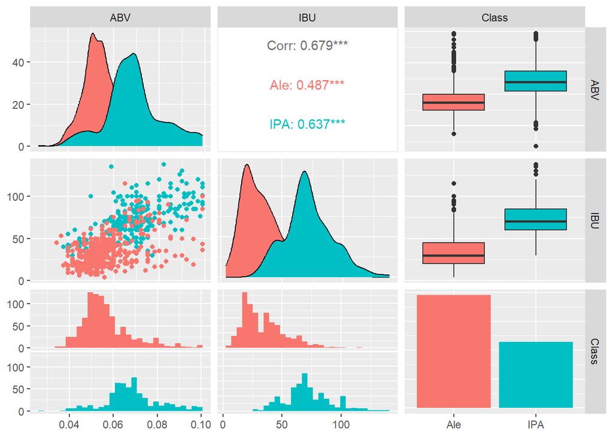

```r
# plot ggpairs by class ipa v. ale
ggpairs_ale_ipa_abv_ibu_by_class <- ale_and_ipa %>%
  select(ABV, IBU, Class) %>%
  ggpairs(aes(color = Class))
ggpairs_ale_ipa_abv_ibu_by_class
```

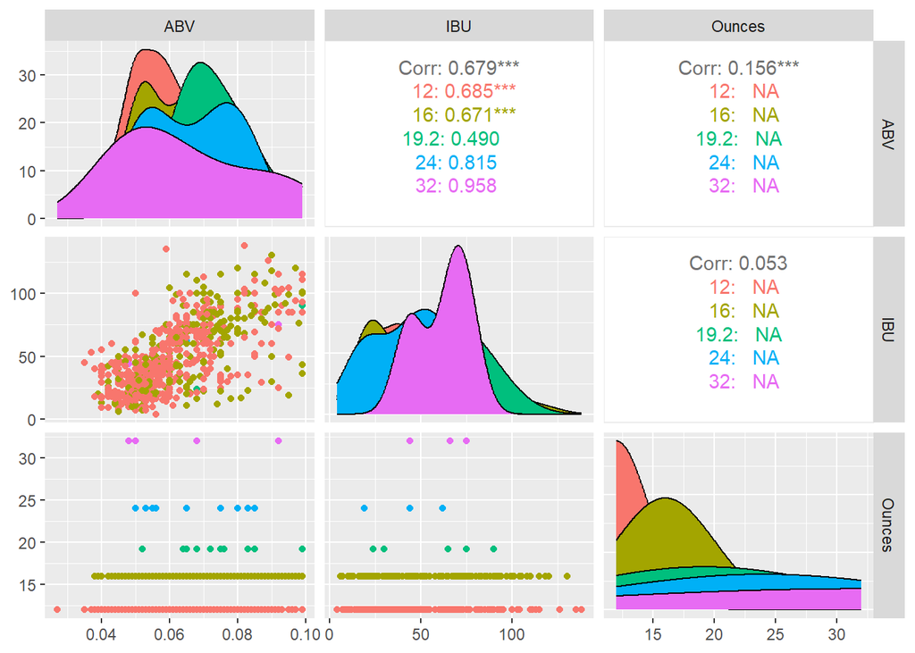

```r
# suppress warning: standard deviation is zero - ABV, IBU NA values

# plot ggpairs by ounce ipa v. ale
ggpairs_ale_ipa_abv_ibu_by_ounces <- ale_and_ipa %>%
  select(ABV, IBU, Ounces) %>%
  ggpairs(aes(na.rm = TRUE, color = as.factor(Ounces)))
ggpairs_ale_ipa_abv_ibu_by_ounces
```

## KNN Classification # Evaluate the ML classification model using K-Nearest Neighbor algorithm to predict ale and IPA class

```r
# install KNN libraries
#install.packages("class")
#install.packages("caret")
#install.packages("e1071")
library(class)
library(caret)
library(e1071)

# count total ale and ipa
count(ale_and_ipa) # 1547 samples total, including NA
```

```
##      n
## 1 1547
```

```r
ale_and_ipa <- na.omit(ale_and_ipa) # omit NA values
count(ale_and_ipa) # omit NA, 951 remain
```

```
##     n
## 1 951
```

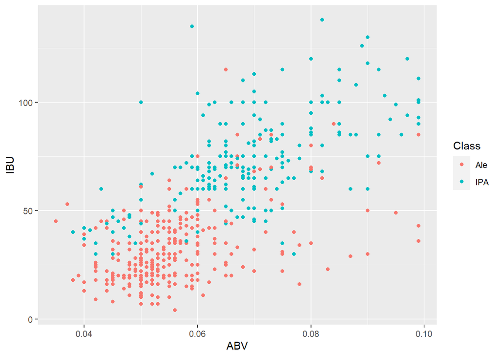

```r
# set up train and test set
trainIndex <- sample(seq(1, 951), 665)
trainBeers <- ale_and_ipa[trainIndex,]
testBeers <- ale_and_ipa[-trainIndex,]

# plot train set
trainBeers %>% ggplot(aes(ABV, IBU, color = Class)) + geom_point()
```

```r
# knn classification
classification = knn(trainBeers[, c("ABV", "IBU")], testBeers[, c("ABV", "IBU")], trainBeers$Class, k = 5, prob = TRUE )
classification
```

[output not shown]

[output cut: 44 more lines]

```r
table <- table(classification, testBeers$Class)
table
```

```
##
## classification Ale IPA
##            Ale 153  21
##            IPA  20  92
```

```r
CM <- confusionMatrix(table, mode = "everything")
CM
```

```
## Confusion Matrix and Statistics
##
##
## classification Ale IPA
##            Ale 153  21
##            IPA  20  92
##
##                Accuracy : 0.8566
##                  95% CI : (0.8106, 0.8951)
##     No Information Rate : 0.6049
##     P-Value [Acc > NIR] : <2e-16
##
##                   Kappa : 0.6996
##
##  Mcnemar's Test P-Value : 1
##
##             Sensitivity : 0.8844
##             Specificity : 0.8142
##          Pos Pred Value : 0.8793
##          Neg Pred Value : 0.8214
##               Precision : 0.8793
##                  Recall : 0.8844
##                      F1 : 0.8818
##              Prevalence : 0.6049
##          Detection Rate : 0.5350
##    Detection Prevalence : 0.6084
##       Balanced Accuracy : 0.8493
##
##        'Positive' Class : Ale
##
```

## Internal LOOCV

# Use leave one out cross validation function to estimate ale and ipa classification model performance

```r
# k = 5, train test only
loocv_classification <- knn.cv(trainBeers[, c("ABV", "IBU")], trainBeers$Class, k = 5)
loocv_classification
```

[output not shown]

[output cut: 23 more lines]

```r
loocv_table <- table(loocv_classification, trainBeers$Class)
loocv_table
```

```
##
## loocv_classification Ale IPA
##                  Ale 348  52
##                  IPA  38 227
```

```r
loocv_cm <- confusionMatrix(loocv_table, mode = "everything")
loocv_cm
```

```
## Confusion Matrix and Statistics
##
##
## loocv_classification Ale IPA
##                  Ale 348  52
##                  IPA  38 227
##
##                Accuracy : 0.8647
##                  95% CI : (0.8363, 0.8897)
##     No Information Rate : 0.5805
##     P-Value [Acc > NIR] : <2e-16
##
##                   Kappa : 0.7202
##
##  Mcnemar's Test P-Value : 0.1706
##
##             Sensitivity : 0.9016
##             Specificity : 0.8136
##          Pos Pred Value : 0.8700
##          Neg Pred Value : 0.8566
##               Precision : 0.8700
##                  Recall : 0.9016
##                      F1 : 0.8855
##              Prevalence : 0.5805
##          Detection Rate : 0.5233
##    Detection Prevalence : 0.6015
##       Balanced Accuracy : 0.8576
##
##        'Positive' Class : Ale
##
```

Above code: KNN support the finding that IBU and ABV seem to be positivly correlated

# PART IX

#9. Knock their socks off! Find one other useful inference from the data that you feel Budweiser may be able to find value in. You must convince them why it is important and back up your conviction with appropriate statistical evidence.

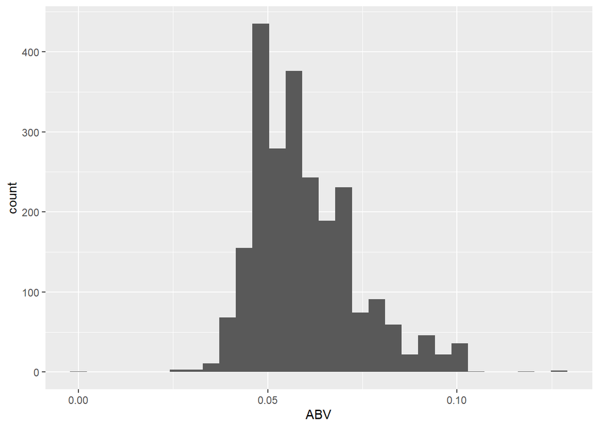

```r
# use of themes and advanced plots
hist_abv <- BEER_AND_BREWERIES %>%
  ggplot(aes(ABV, na.rm = TRUE)) + geom_histogram()
hist_abv
```